# folientest

## Quarto und Revealjs

### Eine kurze Einführung

#### Hanz Hanzen

##### Fachbereich Gesundheitsweisen

###### MHC M3 Spezialwissen 2022

###### 11.10.2021 | MHC

## Quarto und RevealJS

Dies ist eine Vorlage für Folien im HSNR-Design, die mittels `quarto` und `revealjs` gerendert werden.

Allgemeine Informationen finden Sie unter

- https://quarto.org/docs/presentations/revealjs/
- https://quarto.org/docs/presentations/revealjs/presenting.html
- https://quarto.org/docs/presentations/revealjs/advanced.html

```r
1+2+3+4
```

```
[1] 10
```

## HSNR-Vorlage

Alle **notwendigen** *Dateien* *befinden* sich im Unterordner `HSNRtheme`.

Im Ordner `images` liegen die Bilddateien der eigentlichen Präsentation. Dieser Ordner gehört nicht zur Vorlage, sondern ändert sich von Präsentation zu Präsentation.

Schauen Sie sich die Datei `Folientest.qmd` an, um zu sehen, wie diese Folien hier erzeugt wurden.

## Zwischentitel

Die Vorlage bietet zwei “Zwischentitel” an,

- `{.zwischentitel1}`, im dunklen HSNR-Blauton
- `{.zwischentitel2}`, im hellen HSNR-Blauton

# Test

Dies ist ein Zwischentitel  
im dunklen HSNR-Blauton

Dies ist ein Zwischentitel  
im hellen HSNR-Blauton

## Klasse `{.r-fit-text}`

Zusammen mit den Klassen `{.r-fit-text}` und `{.center}` sieht es dann so aus (nächste Folie)…

Dies ist ein  
Zwischentitel

## Farben

Das Theme stellt die die Blautöne der HSNR über die Klassen `{.HSNRblue1}` und `{.HSNRblue2}` zur Verfügung.

- Dies ist HSNRblue1
- Dies ist HSNRblue2

Dies funktioniert auch als Hintergrundfarbe, wenn ein `bg-` vor den Klassennamen geschrieben wird.

- Dies ist .bg-HSNRblue1
- Dies ist .bg-HSNRblue2

## weitere Farben

**Folgende weitere Farben sind im Theme enthalten:**

.gray .silver .light-silver .moon-gray .light-gray .near-white .white .dark-red .red .light-red .orange .gold .yellow .light-yellow .light-purple .dark-pink .hot-pink .pink .light-pink .dark-green .green .light-green .light-blue .lightest-blue .washed-blue .washed-green .washed-yellow .washed-red .black .near-black .dark-gray .mid-gray .dark-red .red .purple .light-purple .dark-pink .dark-green .navy .dark-blue .blue

**Tango-Farben:**

.Tbluedark .Tblue .Tbluelight .Tbrown .Tbrowndark .Tbrownlight .Tgray .Tgraydark .Tgraylight .Tgraylight2 .Tgraylight3 .Tgreen .Tgreendark .Tgreenlight .Tred .Treddark .Tredlight .Tlilac .Tlilacdark .Tlilaclight .Tyellow .Tyellowdark .Tyellowlight .Torange .Torangedark .Torangelight

Die Farben stehen auch als Hintergrundfarben zur Verfügung. Hierfür schreiben Sie einfach ein `bg-` vor den Farbnamen, also z.B. `{.bg-hot-pink}`

## Shadow-Text

Das Theme enthält folgende Schattierungsklassen:

- .shadow-hsnr1
- .shadow-hsnr2
- .shadow-black
- .shadow-silver
- .shadow-grau

## Shadow-Box

Die Klasse `{.shadow-box}` erzeugt eine schattige Kiste

Ich habe ’nen Schatten

## Boxen

Die Klasse `{.instructions}` erzeugt eine umrandete Kiste

Ich bin eine Box

```html
mit eigenem Source-Code-Style
```

## Boxen

Weitere Boxen werden über die Klasse `{.blankbox}` erzeugt.

Ich bin eine Blankbox

Ich bin eine Blankbox mit .bg-HSNRblue2

Ich bin eine Blankbox mit `.bg-light-blue` und `.white`

## Floating Shadow Images

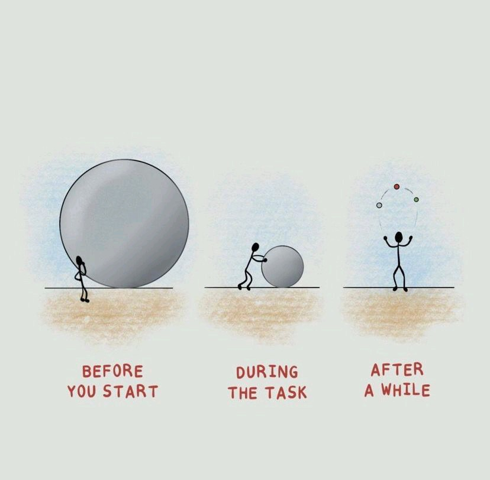

Über die Klassen `{.float-left}`, `{.float-right}` und `{.shadow-img}` können Bilder nach links oder rechts floaten, und sie erhalten einen schattierten Rahmen.

## Zentrieren

Mittels der Klasse `{.tc}` können Inhalte zentriert werden

[figure not shown]

Wau Holland (✝ 2001)

Ich bin ein zentrierter Text!

## Größen (Text)

Mittels der Klasse `{.size0}` bis `{.size150}` kann die Größe der Schrift beeinflusst werden:

Dieser Text ist `.size20`

Dieser Text ist `.size30`

Dieser Text ist `.size40`

Dieser Text ist `.size50`

Prof. Dr. Theo Rethisch | Fachbereich 10 | Hochschule Niederrhein